# Reproducible Research: Peer Assessment 1

SR

8/29/2020

## Loading and preprocessing the data

Code to load data and process/transform the data into a format suitable for analysis

```r
rawdata <- read.csv("activity.csv", header = TRUE)
totsteps <- aggregate(steps~date, data = rawdata, sum, na.rm = TRUE)
head(totsteps)
```

```
##         date steps
## 1 2012-10-02   126
## 2 2012-10-03 11352
## 3 2012-10-04 12116
## 4 2012-10-05 13294
## 5 2012-10-06 15420
## 6 2012-10-07 11015
```

## What is mean total number of steps taken per day?

Histogram of the total number of steps taken each day

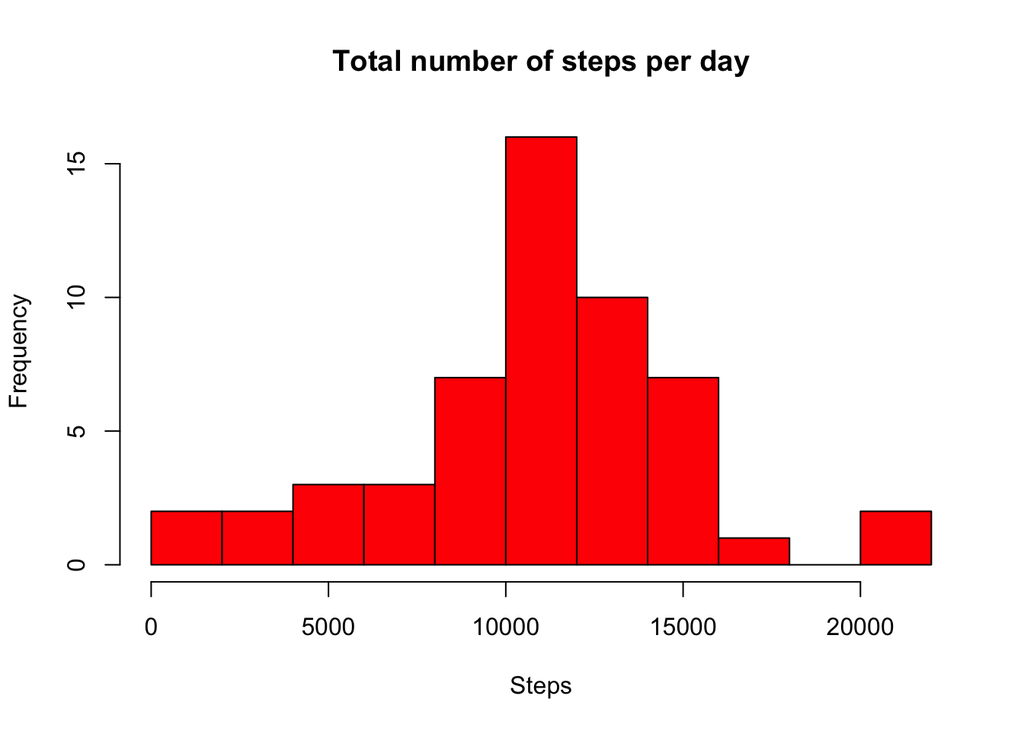

```r
hist(totsteps$steps, col = "red", main = "Total number of steps per day", xlab = "Steps", breaks = 10)
```

The mean and median total number of steps taken per day

```r
mean(totsteps$steps)
```

```
## [1] 10766.19
```

```r
median(totsteps$steps)
```

```
## [1] 10765
```

## What is the average daily activity pattern?

Time series plot of the 5-minute interval (x-axis) and the average number of steps taken, averaged across all days (y-axis)

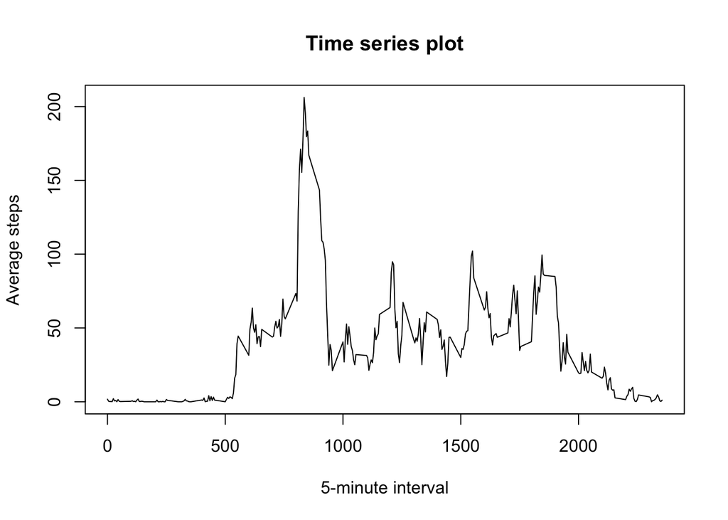

```r
avgsteps <- aggregate(steps~interval,data = rawdata, mean, na.rm = TRUE)
plot(steps~interval, data = avgsteps, type = "l", main = "Time series plot", xlab = "5-minute interval", ylab = "Average steps")
```

The 5-minute interval, on average across all the days in the dataset, that contains the maximum number of steps

```r
avgsteps[which.max(avgsteps$steps),]$interval
```

```
## [1] 835
```

## Imputing missing values

The total number of missing values in the dataset (i.e. the total number of rows with NAs)

```r
sum(is.na(rawdata$steps))
```

```
## [1] 2304
```

Code for filling in all of the missing values in the dataset using the mean and a new dataset that is equal to the original dataset but with the missing data filled in

```r
library(magrittr)
library(dplyr)
replacena <- function(x) replace(x, is.na(x), mean(x, na.rm = TRUE))
newdata <- rawdata%>% group_by(interval) %>% mutate(steps= replacena(steps))
newtotsteps <- aggregate(steps~date, data = newdata, sum, na.rm = TRUE)
head(newtotsteps)
```

```
##         date    steps
## 1 2012-10-01 10766.19
## 2 2012-10-02   126.00
## 3 2012-10-03 11352.00
## 4 2012-10-04 12116.00
## 5 2012-10-05 13294.00
## 6 2012-10-06 15420.00
```

Histogram of the total number of steps taken each day using new data set with missing values replaced by mean.

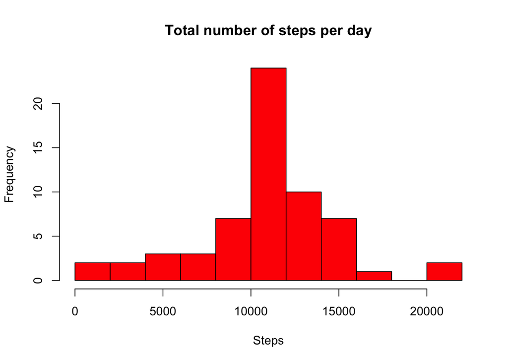

```r
hist(newtotsteps$steps, col = "red", main = "Total number of steps per day", xlab = "Steps", breaks = 10)
```

The mean and median total number of steps taken per day for new data

```r
mean(newtotsteps$steps)
```

```
## [1] 10766.19
```

```r
median(newtotsteps$steps)
```

```
## [1] 10766.19
```

The mean is the same as before but the median is slightly different from the previous value and the same as the mean

## Are there differences in activity patterns between weekdays and weekends?

Code for a new factor variable in the dataset with two levels – “weekday” and “weekend” indicating whether a given date is a weekday or weekend day

```r
weeklydata <- newdata
weeklydata$date <- as.Date(strptime(weeklydata$date, format="%Y-%m-%d"))
weeklydata$day <-  factor(ifelse(as.POSIXlt(weeklydata$date)$wday %in% c(0,6), 'weekend', 'weekday'))
```

Panel plot containing a time series plot of the 5-minute interval (x-axis) and the average number of steps taken, averaged across all weekday days or weekend days (y-axis)

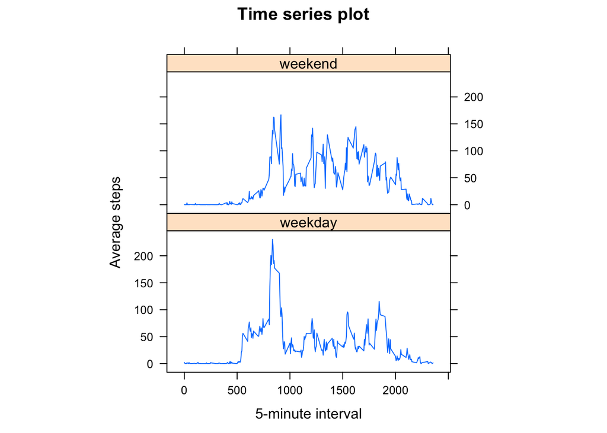

```r
avgweeklysteps <- aggregate(steps ~ interval + day, data = weeklydata, mean)
library(lattice)
xyplot(steps~interval|factor(day), data = avgweeklysteps, aspect = 1/2, type = "l", xlab = "5-minute interval", ylab = "Average steps", main = "Time series plot")
```